# Random forest

```r
data <- read.csv("E:/towork/study/r-studio/projects/R_F/rprojects/randomforrest/data2/CTG.csv", header = TRUE  )
str(data)
```

```
'data.frame':   2126 obs. of  22 variables:
 $ LB      : int  120 132 133 134 132 134 134 122 122 122 ...
 $ AC      : num  0 0.00638 0.00332 0.00256 0.00651 ...
 $ FM      : num  0 0 0 0 0 0 0 0 0 0 ...
 $ UC      : num  0 0.00638 0.00831 0.00768 0.00814 ...
 $ DL      : num  0 0.00319 0.00332 0.00256 0 ...
 $ DS      : num  0 0 0 0 0 0 0 0 0 0 ...
 $ DP      : num  0 0 0 0 0 ...
 $ ASTV    : int  73 17 16 16 16 26 29 83 84 86 ...
 $ MSTV    : num  0.5 2.1 2.1 2.4 2.4 5.9 6.3 0.5 0.5 0.3 ...
 $ ALTV    : int  43 0 0 0 0 0 0 6 5 6 ...
 $ MLTV    : num  2.4 10.4 13.4 23 19.9 0 0 15.6 13.6 10.6 ...
 $ Width   : int  64 130 130 117 117 150 150 68 68 68 ...
 $ Min     : int  62 68 68 53 53 50 50 62 62 62 ...
 $ Max     : int  126 198 198 170 170 200 200 130 130 130 ...
 $ Nmax    : int  2 6 5 11 9 5 6 0 0 1 ...
 $ Nzeros  : int  0 1 1 0 0 3 3 0 0 0 ...
 $ Mode    : int  120 141 141 137 137 76 71 122 122 122 ...
 $ Mean    : int  137 136 135 134 136 107 107 122 122 122 ...
 $ Median  : int  121 140 138 137 138 107 106 123 123 123 ...
 $ Variance: int  73 12 13 13 11 170 215 3 3 1 ...
 $ Tendency: int  1 0 0 1 1 0 0 1 1 1 ...
 $ NSP     : int  2 1 1 1 1 3 3 3 3 3 ...
```

This probabilities is assigned by expert response varible is NSP 1:normal 2:suspect 3:pathologic

convert NSP to Factor

```r
data$NSP <- as.factor(data$NSP)
table(data$NSP)
```

```
   1    2    3
1655  295  176
```

Data partition

```r
set.seed(123)
ind <- sample(2, nrow(data), replace = TRUE,prob = c(0.7,0.3))
train <- data[ind==1,]
test <- data[ind==2,]
```

random forest , aggrigating trees, classification or regression, not overfitting, large number of features, Trees:500, mtry is sq.root & P/3 for regression Ntree bootstrap, each bootstrap sample grow tree, predict majority votes for classification, average for regression

```r
install.packages("randomForest")
library(randomForest)
```

modelling

```r
rf <- randomForest(NSP ~ ., data = train)
print(rf)
```

```
Call:
 randomForest(formula = NSP ~ ., data = train)
               Type of random forest: classification
                     Number of trees: 500
No. of variables tried at each split: 4

        OOB estimate of  error rate: 5.82%
Confusion matrix:
     1   2   3 class.error
1 1141  15   4  0.01637931
2   47 163   3  0.23474178
3    8  10 104  0.14754098
```

```r
attributes(rf)
```

```
$names
 [1] "call"            "type"            "predicted"       "err.rate"        "confusion"       "votes"           "oob.times"
 [8] "classes"         "importance"      "importanceSD"    "localImportance" "proximity"       "ntree"           "mtry"
[15] "forest"          "y"               "test"            "inbag"           "terms"

$class
[1] "randomForest.formula" "randomForest"
```

```r
rf$mtry
```

```
[1] 4
```

prediction and confusion matrix -train data

```r
library(caret)
p1 <- predict(rf, train)
confusionMatrix(p1, train$NSP)
```

```
Confusion Matrix and Statistics

          Reference
Prediction    1    2    3
         1 1160    2    0
         2    0  211    1
         3    0    0  121

Overall Statistics

               Accuracy : 0.998
                 95% CI : (0.9941, 0.9996)
    No Information Rate : 0.7759
    P-Value [Acc > NIR] : < 2.2e-16

                  Kappa : 0.9946

 Mcnemar's Test P-Value : NA

Statistics by Class:

                     Class: 1 Class: 2 Class: 3
Sensitivity            1.0000   0.9906  0.99180
Specificity            0.9940   0.9992  1.00000
Pos Pred Value         0.9983   0.9953  1.00000
Neg Pred Value         1.0000   0.9984  0.99927
Prevalence             0.7759   0.1425  0.08161
Detection Rate         0.7759   0.1411  0.08094
Detection Prevalence   0.7773   0.1418  0.08094
Balanced Accuracy      0.9970   0.9949  0.99590
```

prediction with test data

```r
p2 <- predict(rf, test)
confusionMatrix(p2, test$NSP)
```

```
Confusion Matrix and Statistics

          Reference
Prediction   1   2   3
         1 483  19   4
         2  10  59   4
         3   2   4  46

Overall Statistics

               Accuracy : 0.9319
                 95% CI : (0.9093, 0.9502)
    No Information Rate : 0.7845
    P-Value [Acc > NIR] : <2e-16

                  Kappa : 0.8047

 Mcnemar's Test P-Value : 0.326

Statistics by Class:

                     Class: 1 Class: 2 Class: 3
Sensitivity            0.9758   0.7195  0.85185
Specificity            0.8309   0.9745  0.98960
Pos Pred Value         0.9545   0.8082  0.88462
Neg Pred Value         0.9040   0.9588  0.98618
Prevalence             0.7845   0.1300  0.08558
Detection Rate         0.7655   0.0935  0.07290
Detection Prevalence   0.8019   0.1157  0.08241
Balanced Accuracy      0.9033   0.8470  0.92073
```

error rate we are not to improve the errors after about 300 trees

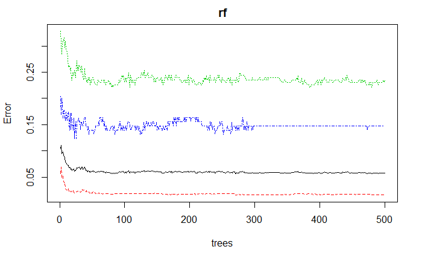

```r
plot(rf)
```

Tune mtry we consider all rows and remove 22 variables and then consider the response variable which is NSP and 22 variable !

```
mtry = 4  OOB error = 5.42%
Searching left ...
mtry = 8    OOB error = 5.15%
0.04938272 0.05
Searching right ...
mtry = 2    OOB error = 6.82%
-0.2592593 0.05
```

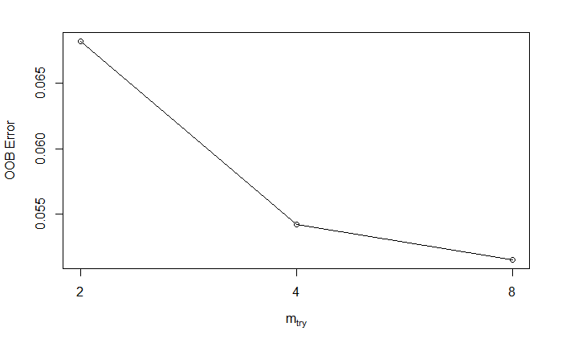

```r
t <- tuneRF(train[,-22], train[,22],
            stepFactor = 0.5,
            plot = TRUE,
            ntreeTry=300,
            trace = TRUE,
            improve = 0.05)
```

again run model and compare the result with pervious results

```r
rf <- randomForest(NSP ~ ., data = train,
                   ntree=300,
                   mtry=8,
                   importance=TRUE,
                   Proximity=TRUE)
print(rf)
```

```
Call:
 randomForest(formula = NSP ~ ., data = train, ntree = 300, mtry = 8,      importance = TRUE, Proximity = TRUE)
               Type of random forest: classification
                     Number of trees: 300
No. of variables tried at each split: 8

        OOB estimate of  error rate: 5.62%
Confusion matrix:
     1   2   3 class.error
1 1136  18   6  0.02068966
2   49 163   1  0.23474178
3    4   6 112  0.08196721
```

```r
p1 <- predict(rf, train)
confusionMatrix(p1, train$NSP)
```

```
Confusion Matrix and Statistics

          Reference
Prediction    1    2    3
         1 1159    1    0
         2    1  212    0
         3    0    0  122

Overall Statistics

               Accuracy : 0.9987
                 95% CI : (0.9952, 0.9998)
    No Information Rate : 0.7759
    P-Value [Acc > NIR] : < 2.2e-16

                  Kappa : 0.9964

 Mcnemar's Test P-Value : NA

Statistics by Class:

                     Class: 1 Class: 2 Class: 3
Sensitivity            0.9991   0.9953  1.00000
Specificity            0.9970   0.9992  1.00000
Pos Pred Value         0.9991   0.9953  1.00000
Neg Pred Value         0.9970   0.9992  1.00000
Prevalence             0.7759   0.1425  0.08161
Detection Rate         0.7753   0.1418  0.08161
Detection Prevalence   0.7759   0.1425  0.08161
Balanced Accuracy      0.9981   0.9973  1.00000
```

```r
p2 <- predict(rf, test)
confusionMatrix(p2, test$NSP)
```

```
Confusion Matrix and Statistics

          Reference
Prediction   1   2   3
         1 479  15   3
         2  14  63   2
         3   2   4  49

Overall Statistics

               Accuracy : 0.9366
                 95% CI : (0.9147, 0.9543)
    No Information Rate : 0.7845
    P-Value [Acc > NIR] : <2e-16

                  Kappa : 0.8231

 Mcnemar's Test P-Value : 0.8252

Statistics by Class:

                     Class: 1 Class: 2 Class: 3
Sensitivity            0.9677  0.76829  0.90741
Specificity            0.8676  0.97086  0.98960
Pos Pred Value         0.9638  0.79747  0.89091
Neg Pred Value         0.8806  0.96558  0.99132
Prevalence             0.7845  0.12995  0.08558
Detection Rate         0.7591  0.09984  0.07765
Detection Prevalence   0.7876  0.12520  0.08716
Balanced Accuracy      0.9177  0.86957  0.94850
```

No of nodes for the trees majority of trees have about 80 nodes

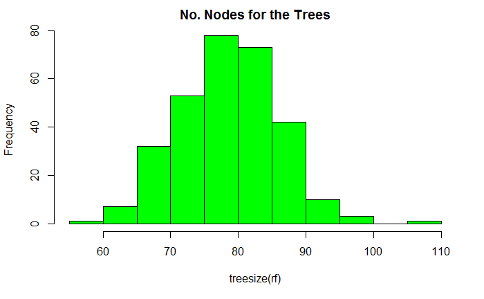

```r
hist(treesize(rf),
     main= "No. Nodes for the Trees",
     col="green")
```